# Multiple linear regression Lab

Andrea Sánchez-Tapia , Paulo Inácio Prado  
2023-01-13

# Introduction

We can extend the simple linear regression model to accommodate multiple predictors. These are the **multiple linear regression** models, of which the simple linear regression is just a particular case with a single predictor variable.

In the next sections we will show how to fit multiple regression models with the least square methods in R, and how to interpret the model coefficients.

# Additive multiple linear model

In a additive multiple linear regression, the expected value of the response $\mu$ is the sum of multiple predictor variables $X_i$, each one weighted by its own coefficient $\beta_i$ :

$$\begin{align}
Y &\sim \mathcal{N}(\mu, \sigma) \\
\mu & = \beta_0 + \beta_1 X_1 + \beta_2 X_2 + \dots + \beta_i X_i \\
\sigma & = C
\end{align}$$

The expression for the predicted value in this model can be written in the compact form:

$$\mu = \sum \beta_i X_i$$

This is called the **linear predictor**.

## Fitting

We will use a data set of an experiment done with the biennial plant *Ipomopsis aggregata*[^1]. Forty plants were assigned at random to two treatments: unprotected from grazing by rabbits and protect from grazing by fences. The fruit yield of each plant (dry mass in mg) was measured at the end of the experiment. To take into account the effect of the size of the plant on fruit production, the diameter of the top of rootstock (mm) was also recorded. Copy the following commands and paste in your R console to read and prepare this data for the analyses:

```r
## Data reading and preparation
ipomopsis <- read.csv("https://raw.githubusercontent.com/lmmx/crawley-r-statistics-book-notes/master/code/ipomopsis.csv")
## More proper names
names(ipomopsis) <-  c("diameter","fruit.w","treatment")
## Convert treatment to a factor variable
ipomopsis$treatment <- factor(ipomopsis$treatment)
```

Let’s start with a plot of the response variable as function of both predictors:

```r
plot(fruit.w ~ diameter, data = ipomopsis, type ="n",
     ylab = "Fruit dry weight (mg)",
     xlab = "Rootstock diamenter (mm)")
points(fruit.w ~ diameter, data = ipomopsis,
       subset = treatment == "Ungrazed")
points(fruit.w ~ diameter, data = ipomopsis,
       subset = treatment == "Grazed", pch=2, col ="red")
legend("topleft", c("Ungrazed", "Grazed"), pch=c(1,2),
       col =c("black", "red"), bty="n")
```

[output not shown]

Larger plants tend to produce a larger dry biomass of fruits. It also seems that if we control for size, ungrazed plants had larger fruit yields. We can check this hypothesis by fitting a linear regression with the additive effect of both plant size and treatment:

```r
ipo_m1 <- lm(fruit.w ~ diameter + treatment, data = ipomopsis)
```

Use the function `coef` to store the coefficients ($\beta_i$) of this fitting in a object:

```r
(ipo_cf1 <- coef(ipo_m1))
```

```
      (Intercept)          diameter treatmentUngrazed
       -127.82936          23.56005          36.10325
```

To add the line of expected yield for grazed plants we can use the function `abline`, that draws a straight line with a given intercept and slope:

```r
## Make the plot again
plot(fruit.w ~ diameter, data = ipomopsis, type ="n",
     ylab = "Fruit dry weight (mg)",
     xlab = "Rootstock diamenter (mm)")
points(fruit.w ~ diameter, data = ipomopsis,
       subset = treatment == "Ungrazed")
points(fruit.w ~ diameter, data = ipomopsis,
       subset = treatment == "Grazed", pch=2, col ="red")
legend("topleft", c("Ungrazed", "Grazed"), pch=c(1,2),
       col =c("black", "red"), bty="n")
## Adds the predicted line for grazed plants
## check the function help to use it
abline( a = ipo_cf1[1], b = ipo_cf1[2], col = "red")
```

[output not shown]

**Challenge:** now add to the plot a black line for the expected yield for ungrazed plants. Your plot should look like this:

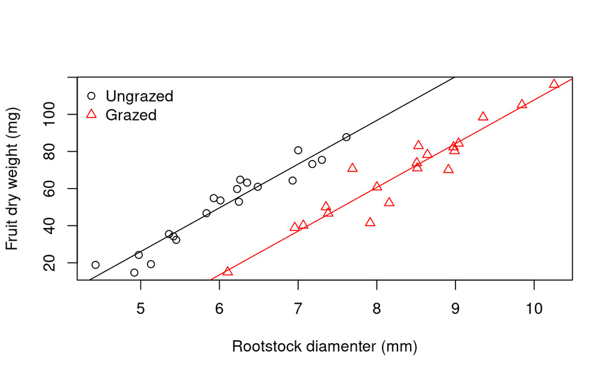

**Final Challenge**

What if we had not controlled for plant size? Fit a model only with the treatment and interpret the coefficients.

Hint: it is good practice to do exploratory data analyses before any model fitting. In this case a box plot can help, try:

```r
boxplot(fruit.w ~ treatment, data=ipomopsis)
```

## Model diagnostics

Before making inferences with your fitted model, it is also a good practice to make some model diagnostics. For linear regression, the most basic diagnostic is to check if the residuals follows a normal distribution with zero mean and a constant standard deviation.

Because the normal distribution has a parameter that corresponds to the expected value, and that is independent of the other parameter, the linear regression model :

$$\begin{align}
Y & \sim \mathcal{N}(\mu, \sigma) \\
\mu & = \sum \beta_i X_i \\
\sigma & = C
\end{align}$$

Can be also written as:

$$\begin{align}
Y & = \sum \beta_i X_i + \epsilon \\
\epsilon & \sim \mathcal{N}(\mu, \sigma) \\
\mu & = 0 \\
\sigma & = C
\end{align}$$

That is, the response $Y$ is a weighted sum of the predictor variables $X_i$ plus a random Gaussian residual $\epsilon$. To express a random variation simetrically around the expected value, this residual has mean value of zero, and a fixed standard deviation.

To check if this assumption is true, we plot the residuals of the fitted model as a function of the predicted values. this plot should show a point cloud of constant width around at zero in the Y-axis. You can check applying the function `plot` to the object that stored the fitted model:

```r
plot(ipo_m1, which =1)
```

[output not shown]

You can also check the normality of the residuals with a qq-plot. Briefly, normal data should lie in a straight line in this plot:

```r
plot(ipo_m1, which =2)
```

[output not shown]

You can find an excellent explanation of these and other diagnostic plots for linear regression [here](https://data.library.virginia.edu/diagnostic-plots/)

[^1]: Crawley 2007. The R Book, Wiley